# Aprendizaje Estadístico y Toma de Decisiones II

Red Neuronal Simple

Juan José Martín Miralles

**A typical neural network application is classification. Consider the simple example of classifying trucks given their masses (in tons) and lengths (in meters):**

| Mass | Length | Class |
| --- | --- | --- |
| 10 | 6 | lorry |
| 20 | 5 | lorry |
| 5 | 4 | van |
| 2 | 5 | van |
| 2 | 5 | van |
| 3 | 6 | lorry |
| 10 | 7 | lorry |
| 15 | 8 | lorry |
| 5 | 9 | lorry |

**How do we construct a neural network that can classify any Lorry and Van? Train the network using the data provided. How would you classify a vehicle with mass 6 and length 6?**

Creamos un dataframe con los datos de la tabla del enunciado.

```r
mass = c(10, 20, 5, 2, 2, 3, 10, 15, 5)
length = c(6, 5, 4, 5, 5, 6, 7, 8, 9)
class = c("lorry", "lorry", "van", "van", "van", "lorry", "lorry", "lorry", "lorry")
df = data.frame(mass, length, class)

df
```

| mass | length | class |
| --- | --- | --- |
| 10 | 6 | lorry |
| 20 | 5 | lorry |
| 5 | 4 | van |
| 2 | 5 | van |
| 2 | 5 | van |
| 3 | 6 | lorry |
| 10 | 7 | lorry |
| 15 | 8 | lorry |
| 5 | 9 | lorry |

# Modelo binario

Creamos la regla de propagación que será:

$$net_k = \sum_{i=1}^n {w_{ik}x_i}$$

donde $w_{ik}$ es el vector de pesos y $x_i$ es el vector de entrada del perceptrón.

```r
weighted.sum = function(a, b) {
  sum(a * b)
}
```

La función de transferencia $F_k$ devolverá un 0 en caso de que $net_k$ sea menor que 0, y un 1 en caso contrario.

```r
binary.step = function(a, b) {
  output = apply(a, 1, weighted.sum, b)
  return(ifelse(output < 0, 0, 1))
}
```

Creo la función para realizar la regla de aprendizaje del perceptrón y que aprenda a clasificar. Se basa en ir cambiando los pesos del vector $W$, que inicialmente los pondré a 0, hasta que no se produzca ningún error de clasificación del conjunto de entrenamiento.

```r
p.binary = function(a, d, learning.rate=1) {
  W = c(0, 0, 0) # initialize W
  k = 0 # count updates
  made.mistake = TRUE # to enter the while loop (error!=0)
  while (made.mistake) {
    made.mistake = FALSE
    yk = binary.step(a, W)
    for (i in 1:nrow(a)) {
      if (d[i] != yk[i]) {
        W = W + learning.rate * (d[i] - yk[i]) * a[i,]
        k = k + 1
        made.mistake = TRUE
        break
      }
    }
  }
  return(list(W = W, updates = k))
}
```

A continuación, entrenamos el modelo. Primero, cambiamos las variables cualitativas, *lorry* y *van*, a cuantitativas con 0 y 1, respectivamente.

```r
df$class_num = ifelse(df$class == 'lorry', 0, 1)

X_train = cbind(1, df$mass, df$length)
y_train = df$class_num

pred_class_binary  = p.binary(X_train, y_train)
pred_class_binary
```

```
## $W
## [1] 40 -2 -6
##
## $updates
## [1] 208
```

Finalmente, comprobamos cómo queda clasificado nuestro conjunto de datos.

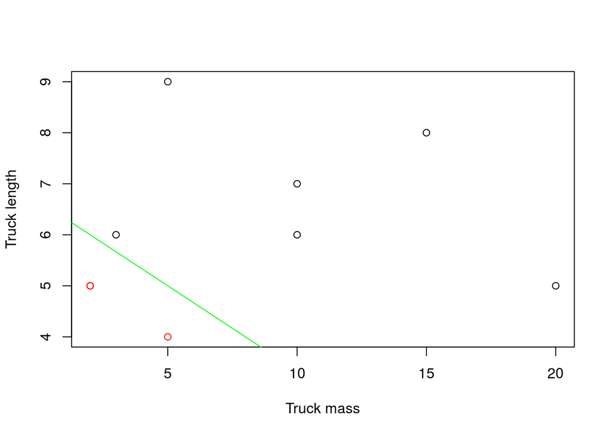

```r
plot(df$mass, df$length, pch = 21,
     col = factor(df$class_num),
     xlab = "Truck mass", ylab = "Truck length")

abline(-pred_class_binary$W[1] / pred_class_binary$W[3], -pred_class_binary$W[2] / pred_class_binary$W[3], col = "green")
```

# Modelo bipolar

Usando la misma regla de propagación, se crea una nueva función de transferencia $F_k$ que, en este caso, devolverá un -1 en caso de que $net_k$ sea menor que 0, y un 1 en caso contrario.

```r
bipolar.step = function(a, b) {
  output = apply(a, 1, weighted.sum, b)
  return(ifelse(output < 0, -1, +1))
}
```

La función para enseñar al perceptrón a clasificar es la misma que para el modelo binario, solo que usa la nueva función de transferencia.

```r
p.bipolar = function(a, d, learning.rate=1) {
  W = c(0, 0, 0) # initialize W
  k = 0 # count updates
  made.mistake = TRUE # to enter the while loop (error!=0)
  while (made.mistake) {
    made.mistake = FALSE
    yk = bipolar.step(a, W)
    for (i in 1:nrow(a)) {
      if (d[i] != yk[i]) {
        W = W + learning.rate * (d[i] - yk[i]) * a[i,]
        k = k + 1
        made.mistake = TRUE
        break
      }
    }
  }
  return(list(W = W, updates = k))
}
```

A continuación, entrenamos el modelo. En este caso, hay que cambiar las variables cualitativas, *lorry* y *van*, a cuantitativas con -1 y 1, respectivamente.

```r
df$class_num = ifelse(df$class == 'lorry', -1, 1)

X_train = cbind(1, df$mass, df$length)
y_train = df$class_num

pred_class_bipolar  = p.bipolar(X_train, y_train)
pred_class_bipolar
```

```
## $W
## [1]  80  -4 -12
##
## $updates
## [1] 208
```

Finalmente, comprobamos cómo queda clasificado nuestro conjunto de datos.

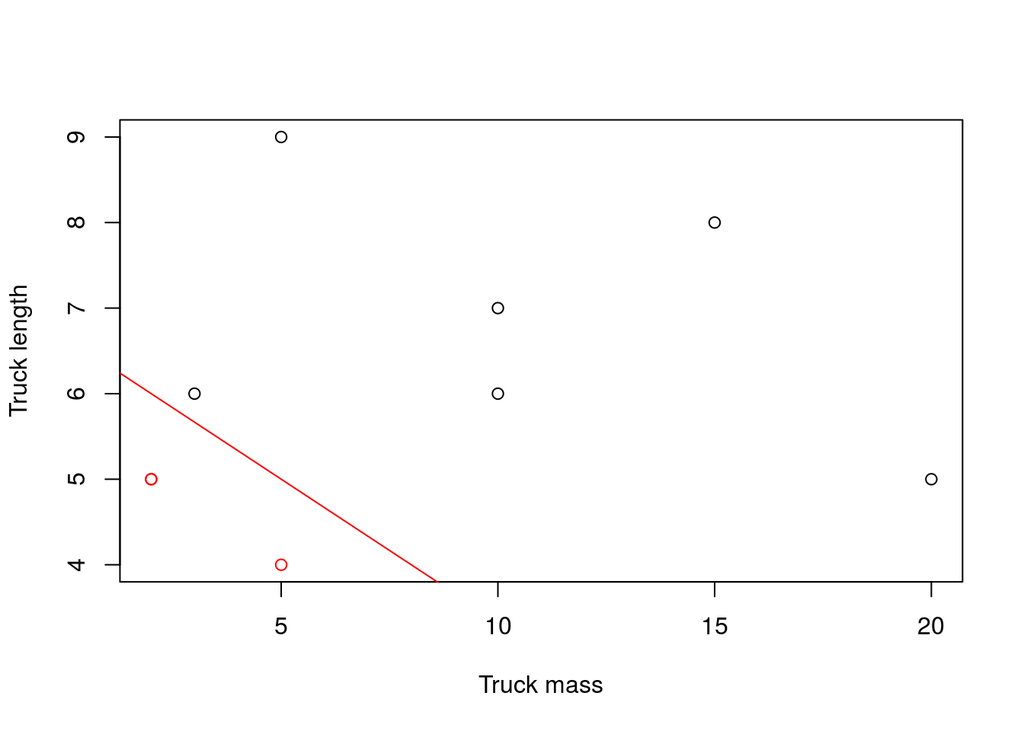

```r
plot(df$mass, df$length, pch = 21,
     col = factor(df$class_num),
     xlab = "Truck mass", ylab = "Truck length")

abline(-pred_class_bipolar$W[1] / pred_class_bipolar$W[3], -pred_class_bipolar$W[2] / pred_class_bipolar$W[3], col = "red")
```

Podemos observar por las gráficas, que ambos modelos han dado prácticamente los mismos resultados.

# Clasificación de nuevos registros

Comprobamos cómo el modelo entrenado clasificaría un nuevo registro que tiene masa 6 y longitud 6. Para ello, usamos las funciones de transferencia definidas anteriormente, a las que les pasamos por parámetro el nuevo registro y los pesos que hemos obtenido con el entrenamiento del percentón en ambos modelos.

```r
new_df = cbind(1, 6, 6)

binary.step(new_df, pred_class_binary$W)
```

```
## [1] 0
```

```r
bipolar.step(new_df, pred_class_bipolar$W)
```

```
## [1] -1
```

Con ambos modelos, el resultado del nuevo registro de masa 6 y longitud 6 ha sido clasificado como **lorry**.